# ARIMA Modeling

## Differencing

When a time series is *trend stationary*, it will have stationary behavior around a trend. A simple example is $Y_t=α+β_t+X_t$ where $X_t$ is stationary.

A different type of model for trend is *random walk*, which has the form $X_t=X_{t−1}+W_t$, where $W_t$ is white noise. It is called a random walk because at time t the process is where it was at time $t−1$ plus a completely random movement. For a random walk with drift, a constant is added to the model and will cause the random walk to drift in the direction (positve or negative) of the drift.

In both cases, simple differencing can remove the trend and coerce the data to stationarity. Differencing looks at the difference between the value of a time series at a certain point in time and its preceding value. That is, $X_t−X_{t−1}$ is computed.

To check that it works, we will difference each generated time series and plot the detrended series. If a time series is in x, then `diff(x)` will have the detrended series obtained by differencing the data. To plot the detrended series, simply use `plot(diff(x))`.

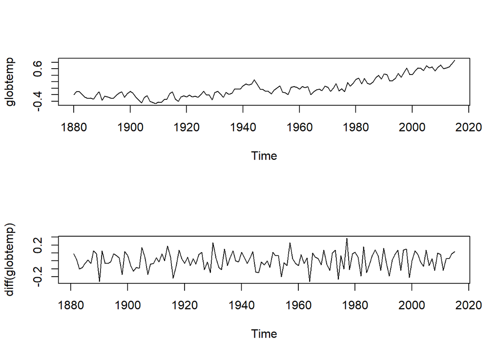

```r
# Plot globtemp and detrended globtemp
par(mfrow = c(2,1))
plot(globtemp)
plot(diff(globtemp))
```

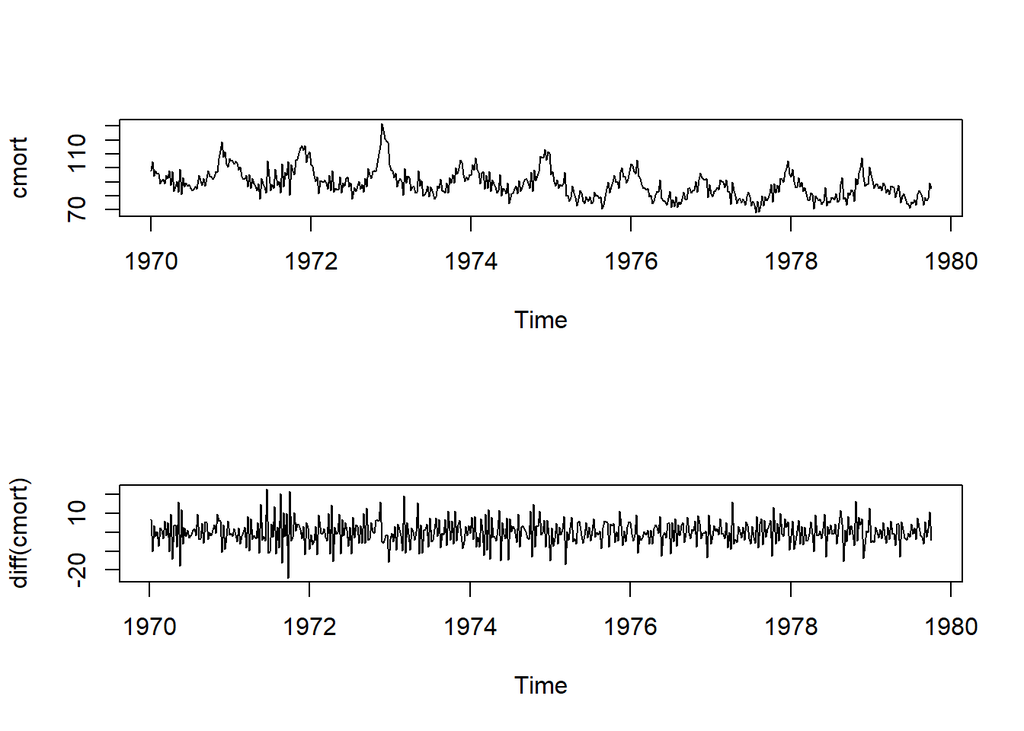

```r
# Plot cmort and detrended cmort
par(mfrow = c(2,1))
plot(cmort)
plot(diff(cmort))
```

## Dealing with Trend and Heteroscedasticity

Here, we will coerce nonstationary data to stationarity by calculating the return or growth rate as follows.

Often time series are generated as $X_t=(1+p_t)X_{t−1}$ meaning that the value of the time series observed at time t equals the value observed at time $t−1$ and a small percent change pt at time $t$.

A simple deterministic example is putting money into a bank with a fixed interest $p$. In this case, $X_t$ is the value of the account at time period t with an initial deposit of $X_0$.

Typically, pt is referred to as the return or growth rate of a time series, and this process is often stable.

For reasons that are outside the scope of this course, it can be shown that the growth rate pt can be approximated by $Y_t=logX_t−logX_t−1≈p_t$.

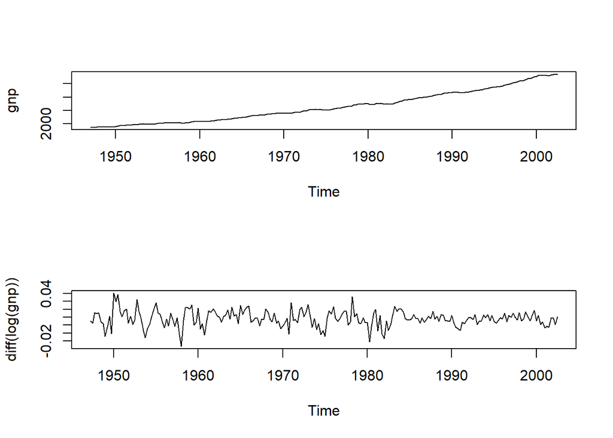

```r
# astsa and xts are preloaded

# Plot GNP series (gnp) and its growth rate
par(mfrow = c(2,1))
plot(gnp)
plot(diff(log(gnp)))
```

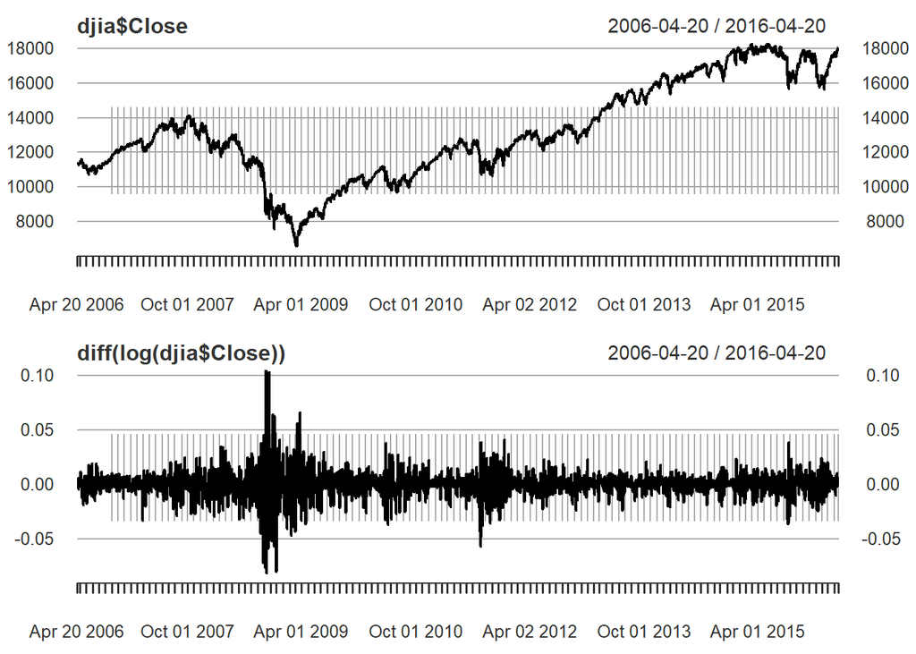

```r
# Plot DJIA closings (djia$Close) and its returns
par(mfrow = c(2,1))
plot(djia$Close)
plot(diff(log(djia$Close)))
```

## Simulating ARMA Models

Any stationary time series can be written as a linear combination of white noise. In addition, any ARMA model has this form, so it is a good choice for modeling stationary time series.

R provides a simple function called `arima.sim()` to generate data from an ARMA model. For example, the syntax for generating 100 observations from an `MA(1)` with parameter `.9` is `arima.sim(model = list(order = c(0, 0, 1), ma = .9 ), n = 100`). We can also use `order = c(0, 0, 0)` to generate white noise.

Now, we will generate data from various ARMA models. For each command, generate 200 observations and plot the result.

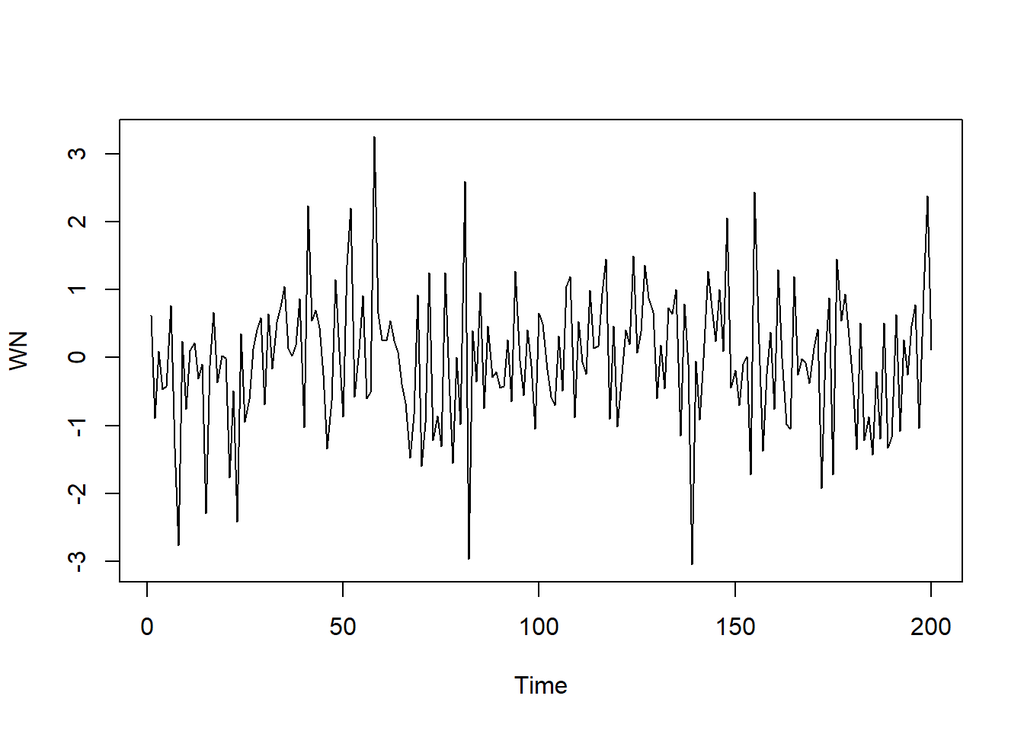

```r
# Generate and plot white noise
WN <- arima.sim(model = list(order = c(0, 0, 0)), n = 200)
plot(WN)
```

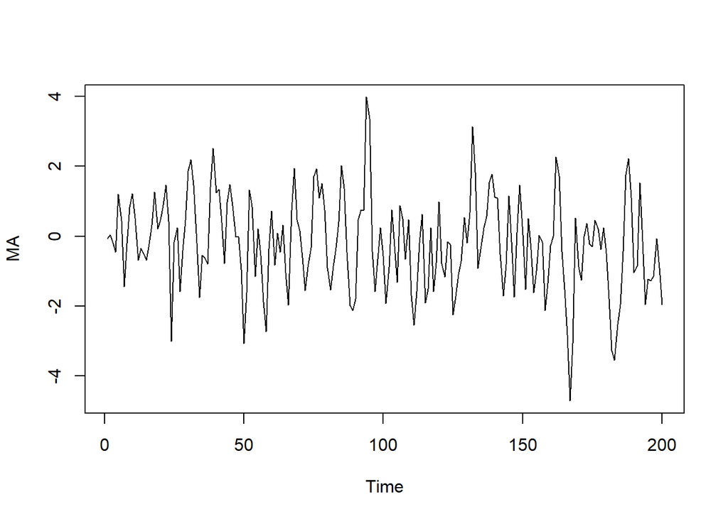

```r
# Generate and plot an MA(1) with parameter .9
MA <- arima.sim(model = list(order = c(0, 0, 1), ma = 0.9), n = 200)
plot(MA)
```

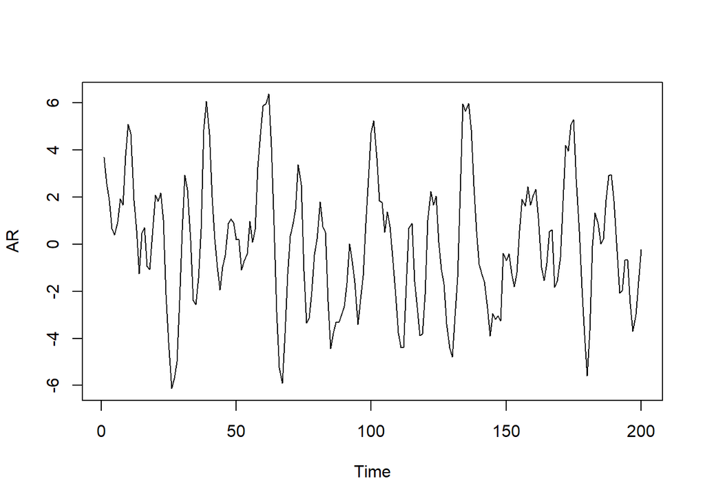

```r
# Generate and plot an AR(2) with parameters 1.5 and -.75
AR <- arima.sim(model = list(order = c(2, 0, 0), ar = c(1.5, -0.75)), n = 200)
plot(AR)
```

# Fitting ARMA models

Discover the wonderful world of ARMA models and how to fit these models to time series data. We will learn how to identify a model, how to choose the correct model, and how to verify a model once we fit it to data. We will learn how to use R time series commands from the stats and astsa packages.

## Fitting an AR(1) Model

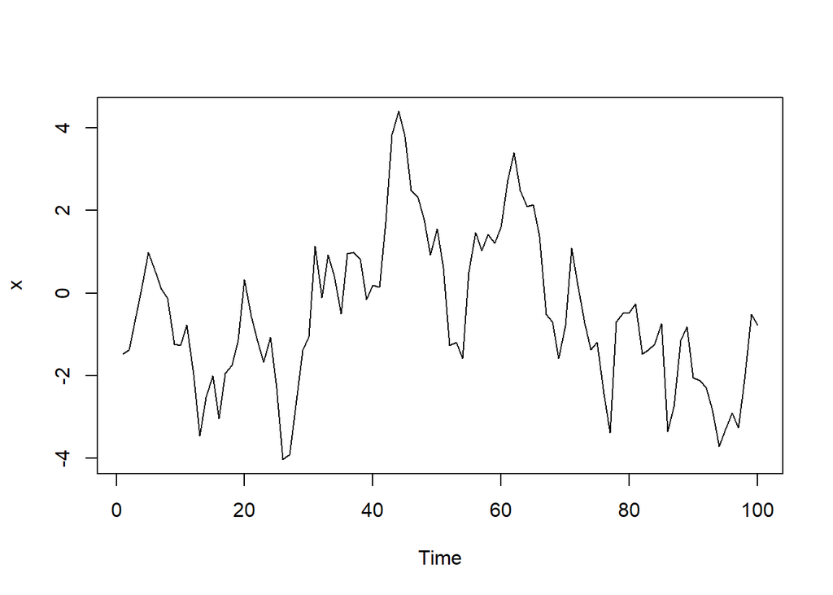

```r
# Generate 100 observations from the AR(1) model
x <- arima.sim(model = list(order = c(1, 0, 0), ar = .9), n = 100)

# Plot the generated data
plot(x)
```

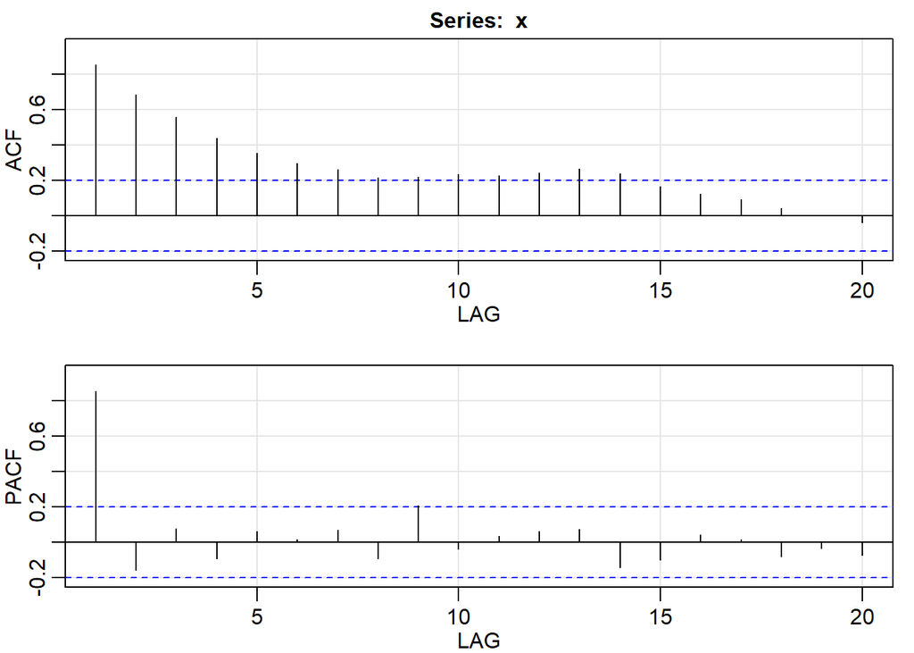

```
##         ACF  PACF
##  [1,]  0.85  0.85
##  [2,]  0.68 -0.16
##  [3,]  0.56  0.08
##  [4,]  0.44 -0.09
##  [5,]  0.35  0.06
##  [6,]  0.29  0.02
##  [7,]  0.26  0.07
##  [8,]  0.21 -0.09
##  [9,]  0.22  0.21
## [10,]  0.23 -0.04
## [11,]  0.23  0.03
## [12,]  0.24  0.06
## [13,]  0.26  0.07
## [14,]  0.24 -0.14
## [15,]  0.17 -0.10
## [16,]  0.12  0.04
## [17,]  0.09  0.02
## [18,]  0.04 -0.08
## [19,]  0.00 -0.03
## [20,] -0.04 -0.07
```

```r
# Plot the sample P/ACF pair
acf2(x)
```

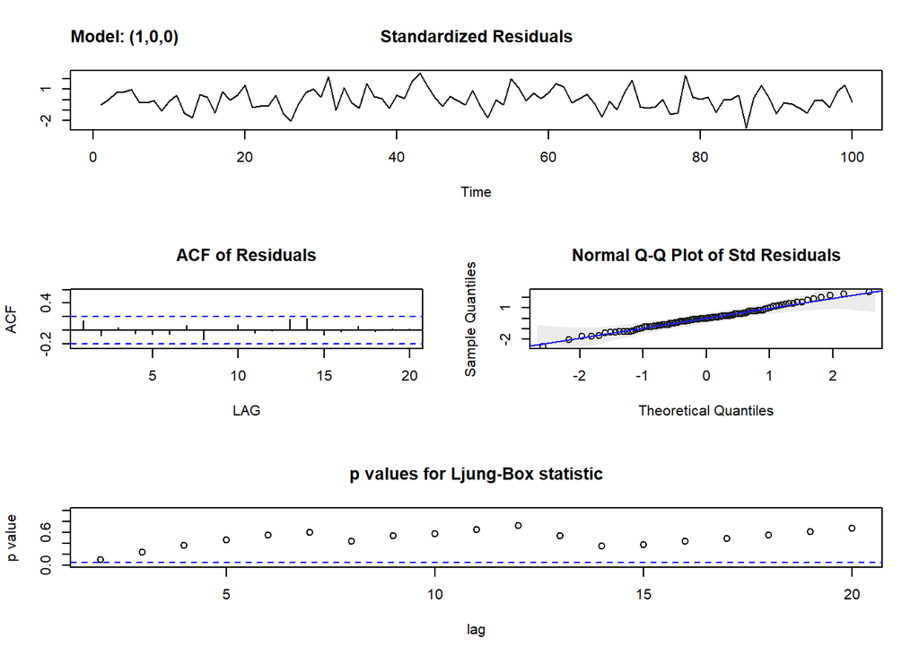

```
## $fit
##
## Call:
## stats::arima(x = xdata, order = c(p, d, q), seasonal = list(order = c(P, D,
##     Q), period = S), xreg = xmean, include.mean = FALSE, optim.control = list(trace = trc,
##     REPORT = 1, reltol = tol))
##
## Coefficients:
##          ar1    xmean
##       0.8458  -0.5511
## s.e.  0.0509   0.5879
##
## sigma^2 estimated as 0.9102:  log likelihood = -137.82,  aic = 281.64
##
## $degrees_of_freedom
## [1] 98
##
## $ttable
##       Estimate     SE t.value p.value
## ar1     0.8458 0.0509 16.6338  0.0000
## xmean  -0.5511 0.5879 -0.9374  0.3509
##
## $AIC
## [1] 0.9459142
##
## $AICc
## [1] 0.9684142
##
## $BIC
## [1] -0.001982403
```

```r
# Fit an AR(1) to the data and examine the t-table
sarima(x, p = 1, d = 0, q = 0)
```

## Fitting an AR(2) Model

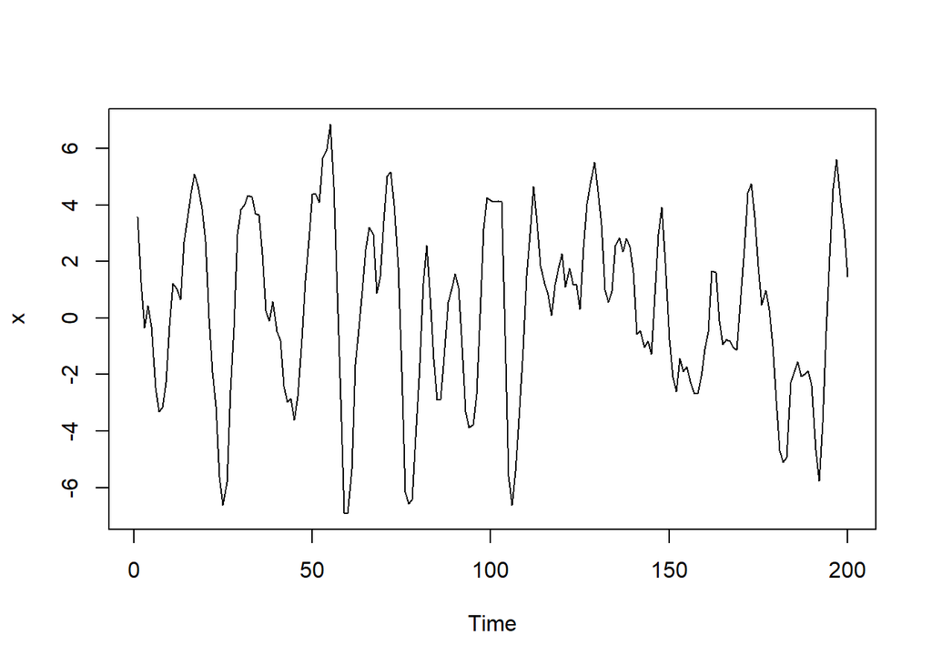

```r
# Plot x
x <- arima.sim(model = list(order = c(2, 0, 0), ar = c(1.5, -.75)), n = 200)
plot(x)
```

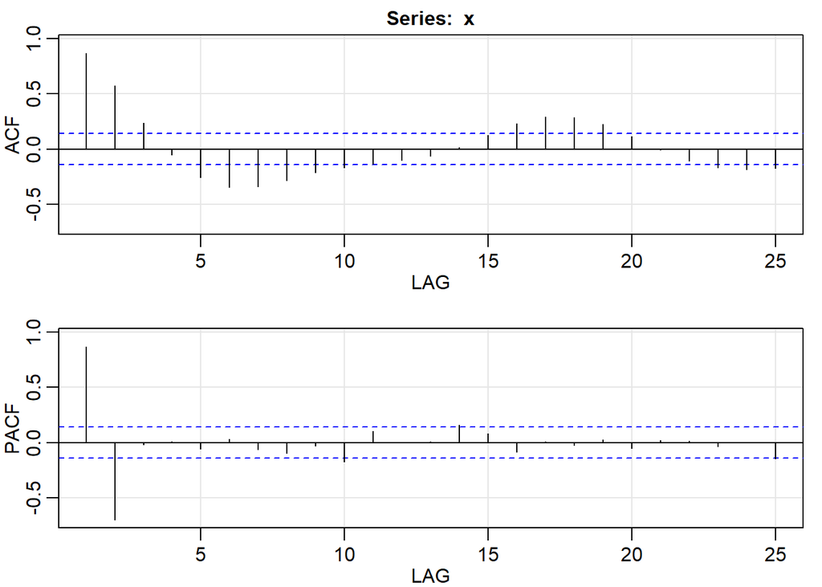

```
##         ACF  PACF
##  [1,]  0.87  0.87
##  [2,]  0.57 -0.70
##  [3,]  0.24 -0.02
##  [4,] -0.05  0.01
##  [5,] -0.25 -0.06
##  [6,] -0.34  0.03
##  [7,] -0.34 -0.06
##  [8,] -0.28 -0.10
##  [9,] -0.21 -0.03
## [10,] -0.17 -0.18
## [11,] -0.13  0.10
## [12,] -0.10  0.00
## [13,] -0.06  0.01
## [14,]  0.02  0.16
## [15,]  0.12  0.08
## [16,]  0.23 -0.08
## [17,]  0.29  0.01
## [18,]  0.29 -0.02
## [19,]  0.22  0.03
## [20,]  0.11 -0.05
## [21,] -0.01  0.02
## [22,] -0.11  0.02
## [23,] -0.17 -0.03
## [24,] -0.18  0.01
## [25,] -0.17 -0.14
```

```r
# Plot the sample P/ACF of x
acf2(x)
```

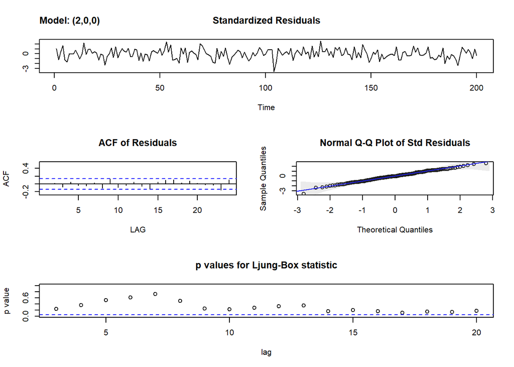

```
## $fit
##
## Call:
## stats::arima(x = xdata, order = c(p, d, q), seasonal = list(order = c(P, D,
##     Q), period = S), xreg = xmean, include.mean = FALSE, optim.control = list(trace = trc,
##     REPORT = 1, reltol = tol))
##
## Coefficients:
##          ar1      ar2   xmean
##       1.4973  -0.7237  0.3246
## s.e.  0.0486   0.0486  0.3338
##
## sigma^2 estimated as 1.145:  log likelihood = -298.73,  aic = 605.47
##
## $degrees_of_freedom
## [1] 197
##
## $ttable
##       Estimate     SE  t.value p.value
## ar1     1.4973 0.0486  30.7940   0.000
## ar2    -0.7237 0.0486 -14.9007   0.000
## xmean   0.3246 0.3338   0.9725   0.332
##
## $AIC
## [1] 1.165025
##
## $AICc
## [1] 1.176051
##
## $BIC
## [1] 0.2144999
```

```r
# Fit an AR(2) to the data and examine the t-table
sarima(x, p = 2, d = 0, q = 0)
```

## Fitting an MA(1) Model

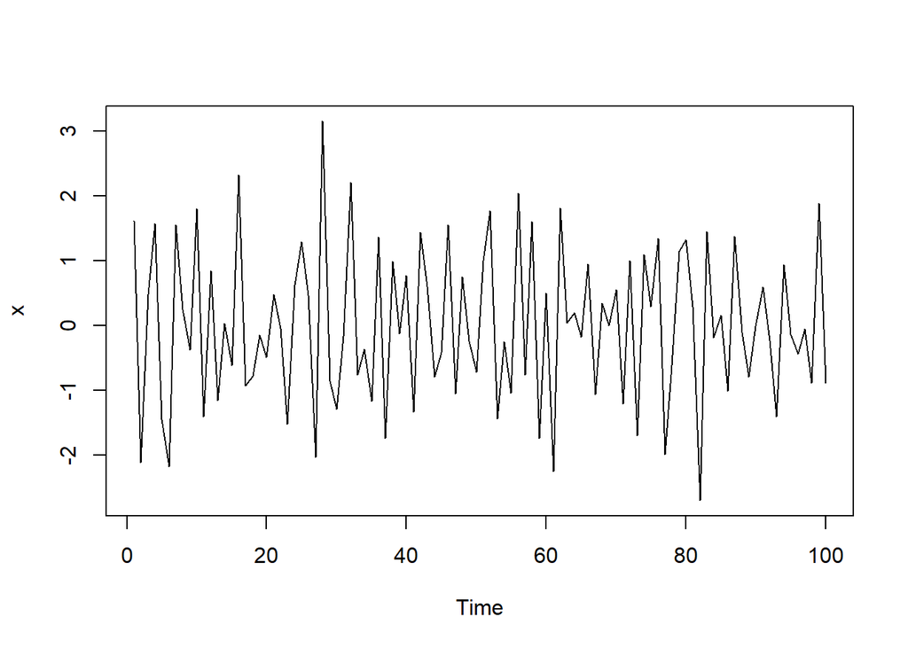

```r
# Plot x
x <- arima.sim(model = list(order = c(0, 0, 1), ma = -.8), n = 100)
plot(x)
```

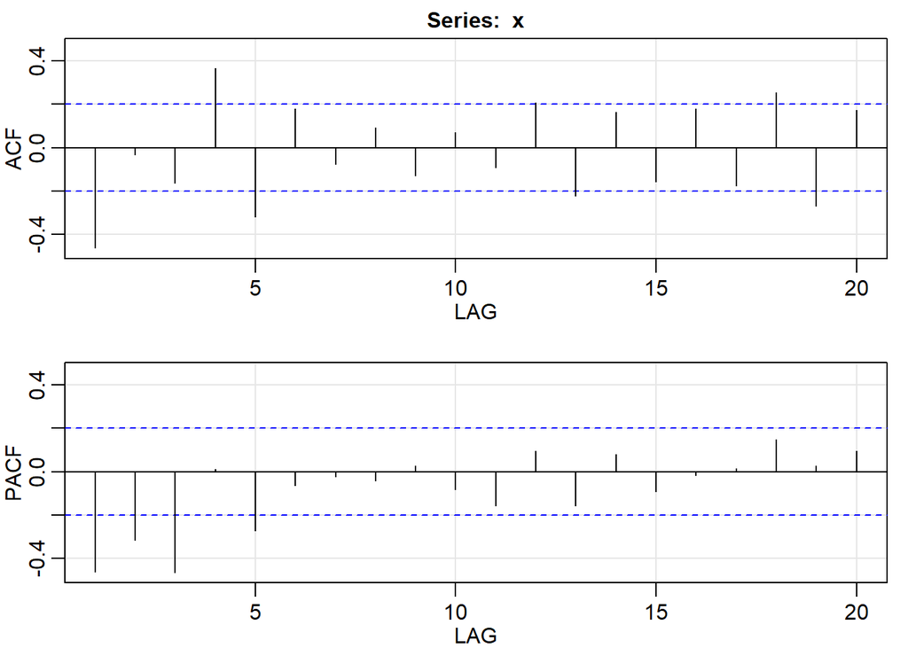

```
##         ACF  PACF
##  [1,] -0.46 -0.46
##  [2,] -0.03 -0.32
##  [3,] -0.16 -0.47
##  [4,]  0.37  0.01
##  [5,] -0.32 -0.27
##  [6,]  0.18 -0.06
##  [7,] -0.08 -0.02
##  [8,]  0.09 -0.04
##  [9,] -0.13  0.03
## [10,]  0.07 -0.08
## [11,] -0.09 -0.16
## [12,]  0.21  0.10
## [13,] -0.22 -0.16
## [14,]  0.16  0.08
## [15,] -0.16 -0.09
## [16,]  0.18 -0.02
## [17,] -0.18  0.01
## [18,]  0.25  0.15
## [19,] -0.27  0.03
## [20,]  0.17  0.10
```

```r
# Plot the sample P/ACF of x
acf2(x)
```

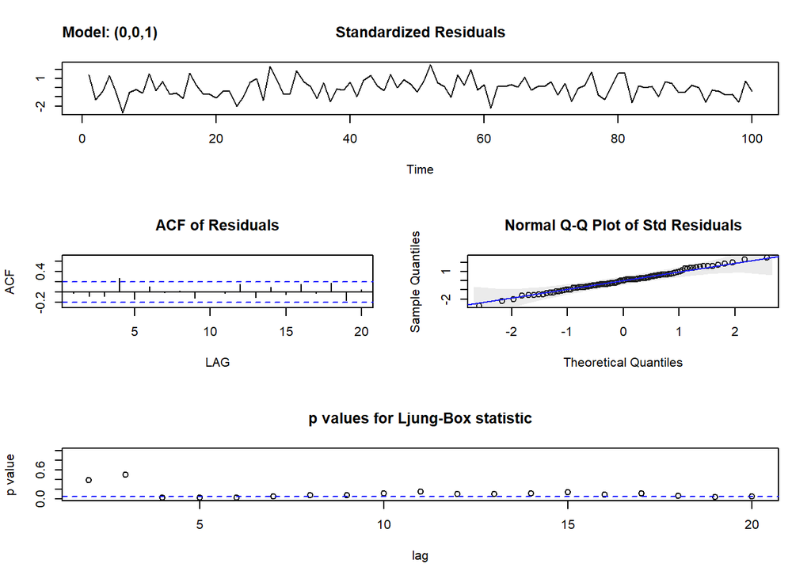

```
## $fit
##
## Call:
## stats::arima(x = xdata, order = c(p, d, q), seasonal = list(order = c(P, D,
##     Q), period = S), xreg = xmean, include.mean = FALSE, optim.control = list(trace = trc,
##     REPORT = 1, reltol = tol))
##
## Coefficients:
##           ma1   xmean
##       -0.8285  0.0094
## s.e.   0.0538  0.0167
##
## sigma^2 estimated as 0.8359:  log likelihood = -133.51,  aic = 273.02
##
## $degrees_of_freedom
## [1] 98
##
## $ttable
##       Estimate     SE  t.value p.value
## ma1    -0.8285 0.0538 -15.3923   0.000
## xmean   0.0094 0.0167   0.5656   0.573
##
## $AIC
## [1] 0.8607767
##
## $AICc
## [1] 0.8832767
##
## $BIC
## [1] -0.08711994
```

```r
# Fit an MA(1) to the data and examine the t-table
sarima(x, p = 0, d = 0, q = 1)
```

## Fitting an ARMA model

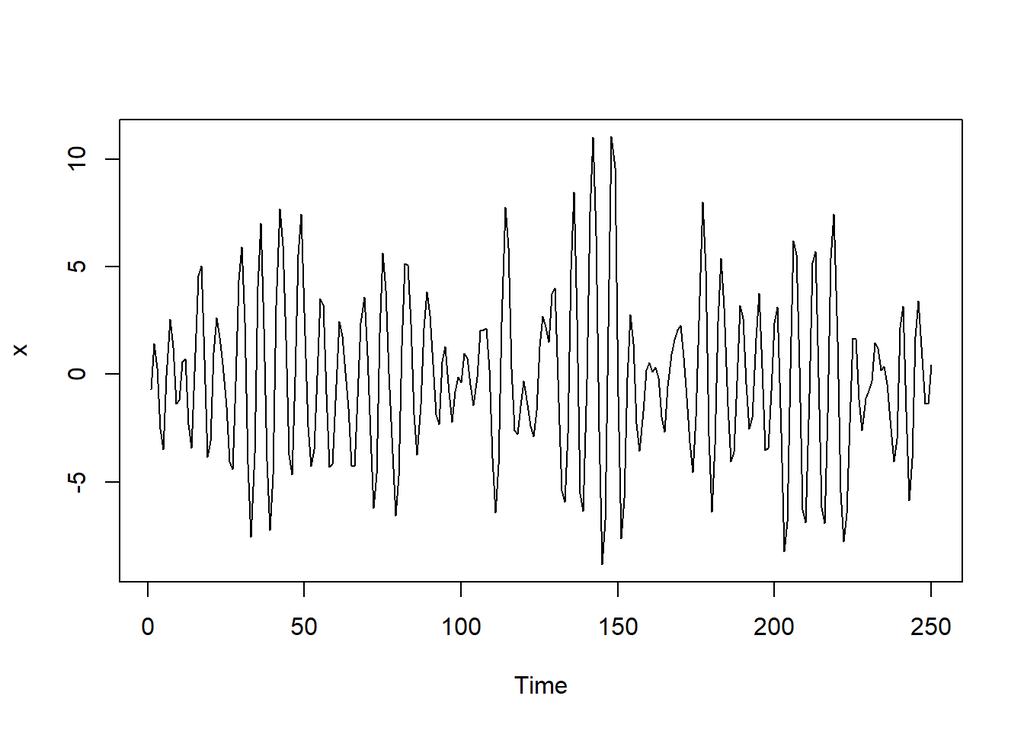

```r
x <- arima.sim(model = list(order = c(2, 0, 1), ar = c(1, -.9), ma = .8), n = 250)

# Plot x
plot(x)
```

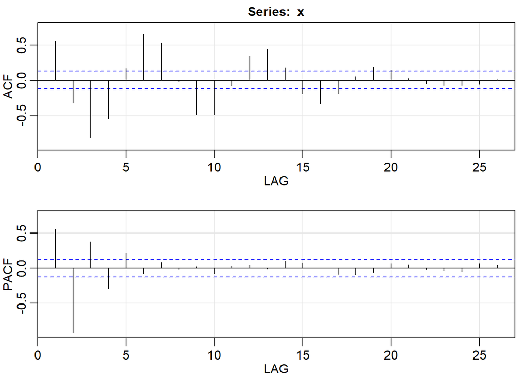

```
##         ACF  PACF
##  [1,]  0.56  0.56
##  [2,] -0.32 -0.92
##  [3,] -0.82  0.38
##  [4,] -0.55 -0.29
##  [5,]  0.16  0.21
##  [6,]  0.65 -0.08
##  [7,]  0.53  0.08
##  [8,] -0.03 -0.01
##  [9,] -0.49  0.02
## [10,] -0.49 -0.08
## [11,] -0.08  0.03
## [12,]  0.35  0.04
## [13,]  0.44 -0.01
## [14,]  0.17  0.10
## [15,] -0.19  0.08
## [16,] -0.34  0.00
## [17,] -0.19 -0.09
## [18,]  0.06 -0.09
## [19,]  0.19 -0.06
## [20,]  0.14  0.06
## [21,]  0.03  0.05
## [22,] -0.05 -0.01
## [23,] -0.08 -0.03
## [24,] -0.08 -0.05
## [25,] -0.06  0.06
## [26,]  0.01  0.04
```

```r
# Plot the sample P/ACF of x
acf2(x)
```

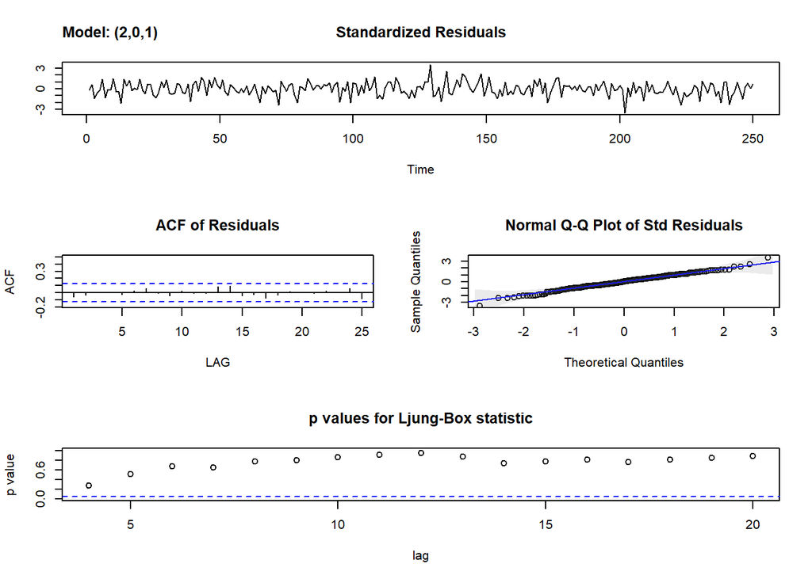

```
## $fit
##
## Call:
## stats::arima(x = xdata, order = c(p, d, q), seasonal = list(order = c(P, D,
##     Q), period = S), xreg = xmean, include.mean = FALSE, optim.control = list(trace = trc,
##     REPORT = 1, reltol = tol))
##
## Coefficients:
##          ar1      ar2     ma1    xmean
##       0.9823  -0.8654  0.8360  -0.1779
## s.e.  0.0315   0.0309  0.0393   0.1303
##
## sigma^2 estimated as 0.979:  log likelihood = -355.11,  aic = 720.21
##
## $degrees_of_freedom
## [1] 246
##
## $ttable
##       Estimate     SE  t.value p.value
## ar1     0.9823 0.0315  31.1592  0.0000
## ar2    -0.8654 0.0309 -27.9836  0.0000
## ma1     0.8360 0.0393  21.2563  0.0000
## xmean  -0.1779 0.1303  -1.3652  0.1734
##
## $AIC
## [1] 1.01073
##
## $AICc
## [1] 1.019713
##
## $BIC
## [1] 0.06707288
```

```r
# Fit an ARMA(2,1) to the data and examine the t-table
sarima(x, p = 2, d = 0, q = 1)
```

## Model Choice - I

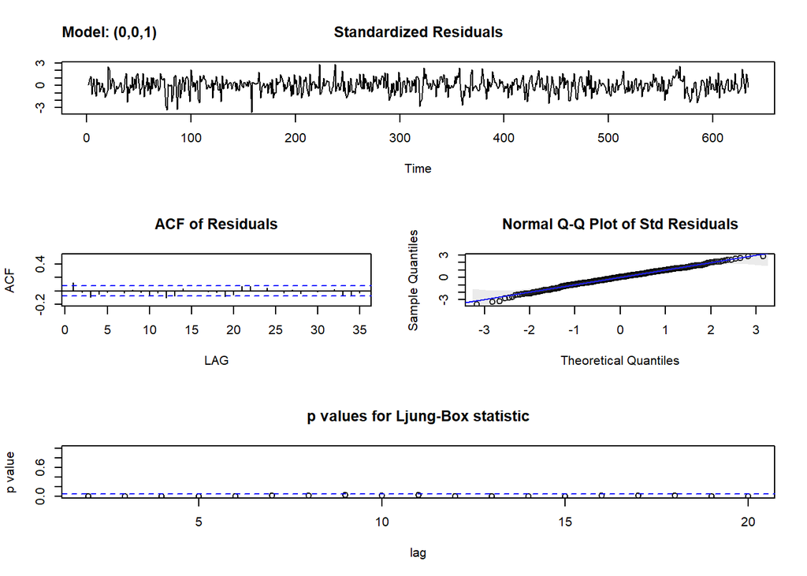

```
## $fit
##
## Call:
## stats::arima(x = xdata, order = c(p, d, q), seasonal = list(order = c(P, D,
##     Q), period = S), xreg = xmean, include.mean = FALSE, optim.control = list(trace = trc,
##     REPORT = 1, reltol = tol))
##
## Coefficients:
##           ma1    xmean
##       -0.7710  -0.0013
## s.e.   0.0341   0.0044
##
## sigma^2 estimated as 0.2353:  log likelihood = -440.68,  aic = 887.36
##
## $degrees_of_freedom
## [1] 631
##
## $ttable
##       Estimate     SE  t.value p.value
## ma1    -0.7710 0.0341 -22.6002  0.0000
## xmean  -0.0013 0.0044  -0.2818  0.7782
##
## $AIC
## [1] -0.4406366
##
## $AICc
## [1] -0.4374168
##
## $BIC
## [1] -1.426575
```

```r
dl_varve <- diff(log(varve))

# Fit an MA(1) to dl_varve.
sarima(dl_varve, p = 0, d = 0, q = 1)
```

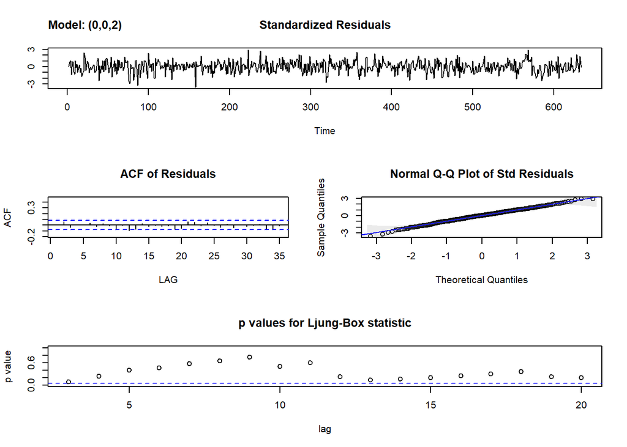

```
## $fit
##
## Call:
## stats::arima(x = xdata, order = c(p, d, q), seasonal = list(order = c(P, D,
##     Q), period = S), xreg = xmean, include.mean = FALSE, optim.control = list(trace = trc,
##     REPORT = 1, reltol = tol))
##
## Coefficients:
##           ma1      ma2    xmean
##       -0.6710  -0.1595  -0.0013
## s.e.   0.0375   0.0392   0.0033
##
## sigma^2 estimated as 0.2294:  log likelihood = -432.69,  aic = 873.39
##
## $degrees_of_freedom
## [1] 630
##
## $ttable
##       Estimate     SE  t.value p.value
## ma1    -0.6710 0.0375 -17.9057  0.0000
## ma2    -0.1595 0.0392  -4.0667  0.0001
## xmean  -0.0013 0.0033  -0.4007  0.6888
##
## $AIC
## [1] -0.4629629
##
## $AICc
## [1] -0.4597027
##
## $BIC
## [1] -1.441871
```

```r
# Fit an MA(2) to dl_varve. Improvement?
sarima(dl_varve, p = 0, d = 0, q =2)
```

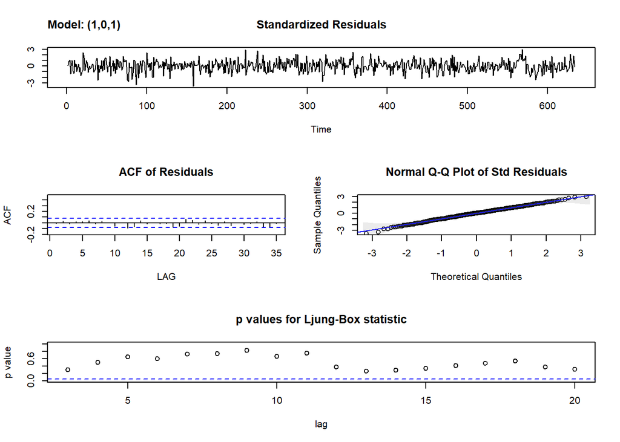

```
## $fit
##
## Call:
## stats::arima(x = xdata, order = c(p, d, q), seasonal = list(order = c(P, D,
##     Q), period = S), xreg = xmean, include.mean = FALSE, optim.control = list(trace = trc,
##     REPORT = 1, reltol = tol))
##
## Coefficients:
##          ar1      ma1    xmean
##       0.2341  -0.8871  -0.0013
## s.e.  0.0518   0.0292   0.0028
##
## sigma^2 estimated as 0.2284:  log likelihood = -431.33,  aic = 870.66
##
## $degrees_of_freedom
## [1] 630
##
## $ttable
##       Estimate     SE  t.value p.value
## ar1     0.2341 0.0518   4.5184  0.0000
## ma1    -0.8871 0.0292 -30.4107  0.0000
## xmean  -0.0013 0.0028  -0.4618  0.6444
##
## $AIC
## [1] -0.467376
##
## $AICc
## [1] -0.4641159
##
## $BIC
## [1] -1.446284
```

```r
# Fit an ARMA(1,1) to dl_varve. Improvement?
sarima(dl_varve, p = 1, d = 0, q = 1)
```

## ARMA get in

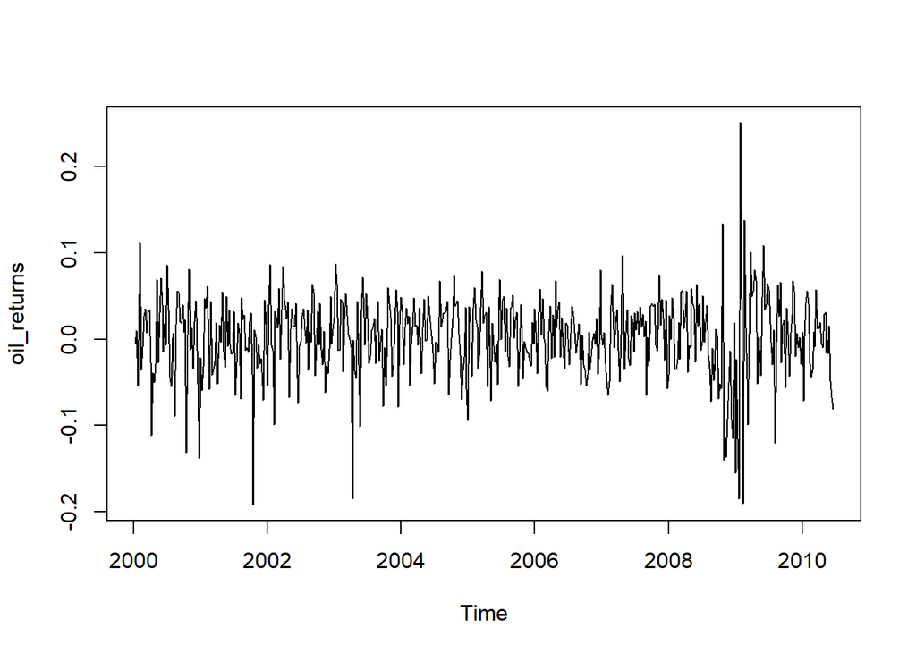

```r
# Calculate approximate oil returns
oil_returns <- diff(log(oil))

# Plot oil_returns. Notice the outliers.
plot(oil_returns)
```

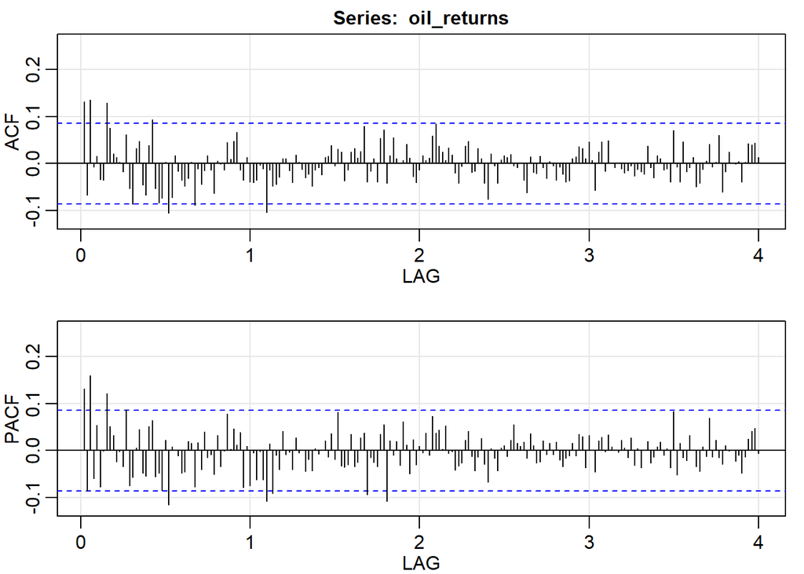

```
##          ACF  PACF
##   [1,]  0.13  0.13
##   [2,] -0.07 -0.09
##   [3,]  0.13  0.16
##   [4,] -0.01 -0.06
##   [5,]  0.02  0.05
##   [6,] -0.03 -0.08
##   [7,] -0.03  0.00
##   [8,]  0.13  0.12
##   [9,]  0.08  0.05
##  [10,]  0.02  0.03
##  [11,]  0.01 -0.02
##  [12,]  0.00  0.00
##  [13,] -0.02 -0.03
##  [14,]  0.06  0.09
```

[output cut: 194 more lines]

```r
# Plot the P/ACF pair for oil_returns
acf2(oil_returns)
```

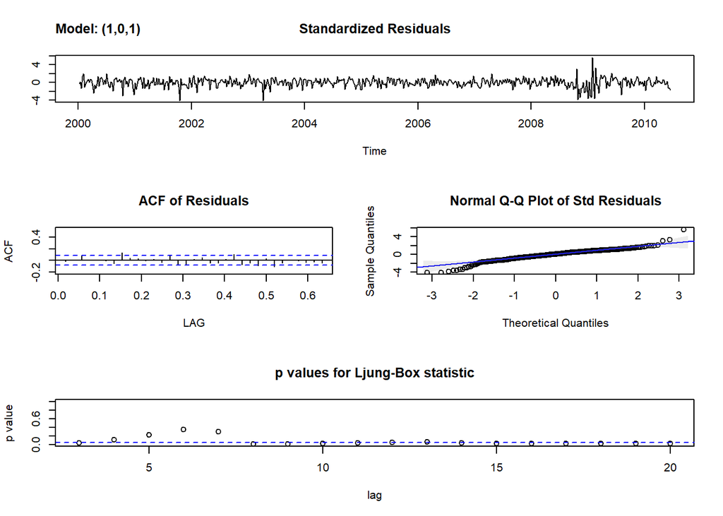

```
## $fit
##
## Call:
## stats::arima(x = xdata, order = c(p, d, q), seasonal = list(order = c(P, D,
##     Q), period = S), xreg = xmean, include.mean = FALSE, optim.control = list(trace = trc,
##     REPORT = 1, reltol = tol))
##
## Coefficients:
##           ar1     ma1   xmean
##       -0.5264  0.7146  0.0018
## s.e.   0.0871  0.0683  0.0022
##
## sigma^2 estimated as 0.002102:  log likelihood = 904.89,  aic = -1801.79
##
## $degrees_of_freedom
## [1] 541
##
## $ttable
##       Estimate     SE t.value p.value
## ar1    -0.5264 0.0871 -6.0422  0.0000
## ma1     0.7146 0.0683 10.4699  0.0000
## xmean   0.0018 0.0022  0.7981  0.4252
##
## $AIC
## [1] -5.153838
##
## $AICc
## [1] -5.150025
##
## $BIC
## [1] -6.130131
```

```r
# Assuming both P/ACF are tailing, fit a model to oil_returns
sarima(oil_returns, p = 1, d = 0, q = 1)
```

# ARIMA Models

Now that we know how to fit ARMA models to stationary time series, we will learn about integrated ARMA (ARIMA) models for nonstationary time series. we will fit the models to real data using R time series commands from the stats and astsa packages.

## ARIMA - Plug and Play

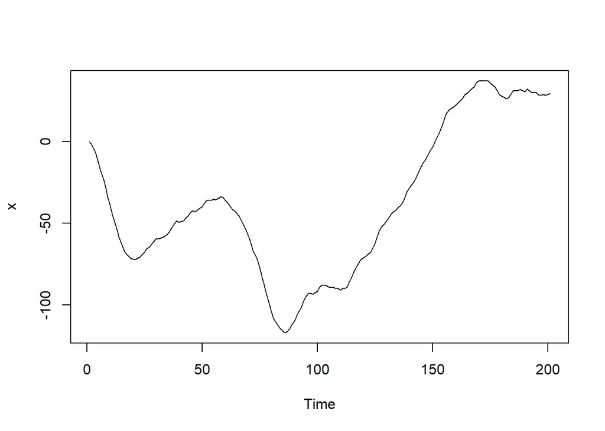

```r
x <- arima.sim(model = list(order = c(1, 1, 0), ar = .9), n = 200)
# Plot x
plot(x)
```

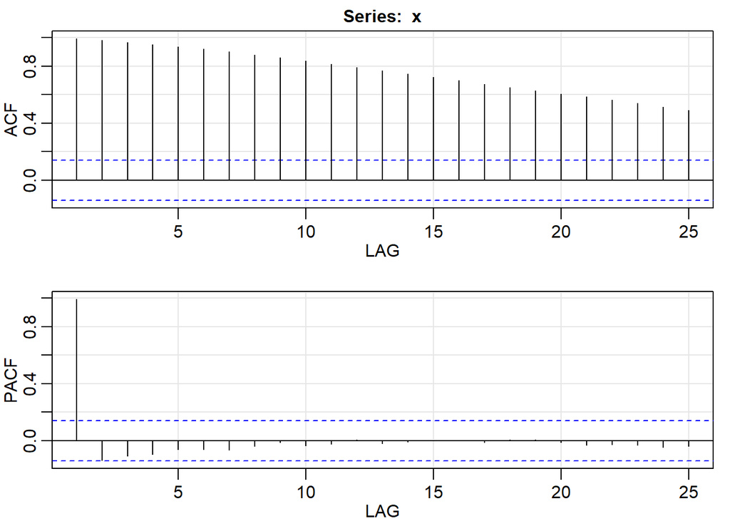

```
##        ACF  PACF
##  [1,] 0.99  0.99
##  [2,] 0.98 -0.14
##  [3,] 0.97 -0.11
##  [4,] 0.95 -0.10
##  [5,] 0.94 -0.06
##  [6,] 0.92 -0.06
##  [7,] 0.90 -0.07
##  [8,] 0.88 -0.04
##  [9,] 0.86 -0.01
## [10,] 0.84 -0.03
## [11,] 0.81 -0.02
## [12,] 0.79  0.00
## [13,] 0.77 -0.02
## [14,] 0.74 -0.01
## [15,] 0.72  0.00
## [16,] 0.70  0.00
## [17,] 0.67 -0.01
## [18,] 0.65  0.01
## [19,] 0.63  0.01
## [20,] 0.61 -0.01
## [21,] 0.58 -0.03
## [22,] 0.56 -0.03
## [23,] 0.54 -0.03
## [24,] 0.51 -0.05
## [25,] 0.49 -0.04
```

```r
# Plot the P/ACF pair of x
acf2(x)
```

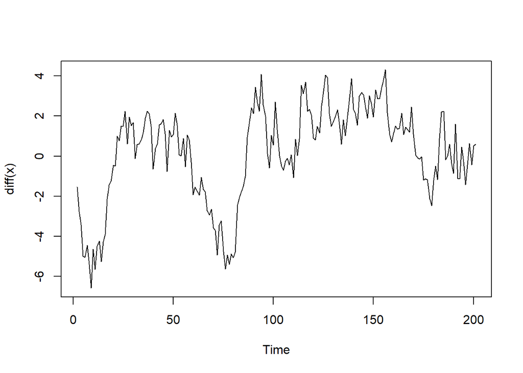

```r
# Plot the differenced data
plot(diff(x))
```

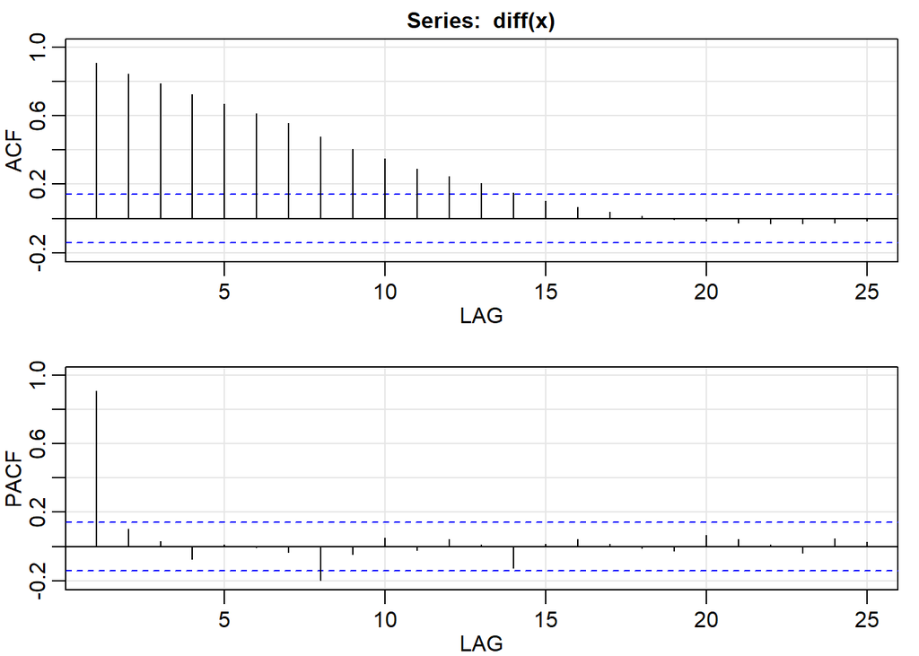

```
##         ACF  PACF
##  [1,]  0.91  0.91
##  [2,]  0.85  0.10
##  [3,]  0.79  0.03
##  [4,]  0.72 -0.08
##  [5,]  0.67  0.01
##  [6,]  0.61 -0.01
##  [7,]  0.56 -0.03
##  [8,]  0.48 -0.20
##  [9,]  0.40 -0.04
## [10,]  0.35  0.05
## [11,]  0.29 -0.02
## [12,]  0.25  0.04
## [13,]  0.21  0.01
## [14,]  0.15 -0.13
## [15,]  0.10  0.01
## [16,]  0.07  0.04
## [17,]  0.04  0.02
## [18,]  0.01 -0.01
## [19,] -0.01 -0.03
## [20,] -0.01  0.06
## [21,] -0.02  0.04
## [22,] -0.03  0.01
## [23,] -0.03 -0.04
## [24,] -0.02  0.04
## [25,] -0.01  0.03
```

```r
# Plot the P/ACF pair of the differenced data
acf2(diff(x))
```